# Washington: Zip-Level Wildfire Smoke and Health Outcomes for Manuscript

Ryan Gan

December 18, 2016

## Overview

This document contains results for the association between wildfire smoke PM<sub>2.5</sub> and cardiovascular (CVD) and respiratory health outcomes. This particular markdown document focuses on the zip code-level analysis. Note there is a county-level analysis that will be paired with CDC mortality data as well. Herein, I compare different PM<sub>2.5</sub> estimation methods described in further detail below.

Note, epidemiological methods that Sheryl and I think can improve our estimation and reduce some bias around the point estimates will not be the focus of the manuscript.

## Methods Description

In these comparisons, we examine various methods of smoke/PM<sub>2.5</sub> estimations and associations with health outcomes using a time-stratified case-crossover study design. Health outcomes for a patient with a primary diagnosis of cardiopulmonary health outcomes and their date of admission (index time) were identified. We then created counterfactual observations for each patient for the same day of the week for the entire wildfire season (July 1st to Octboer 31st, 2012). We further limited our analyses to claims that were coded as emergency or urgent visits to eliminate bias from patients going in for elective/planned procedures. For patients who have a index time closer to July 1, 2012 or closer to October 31, 2012, their referent observations before or after these dates will be excluded as I will not be able to assign estimates of PM<sub>2.5</sub> to these referent observations. However, this is not a big issue for a time-stratified design as other referent values throughout the time period average out.

The **health outcomes** of interest are all respiratory, asthma, COPD, pneumonia, acute bronchitis, cardiovascular disease, heart failure, ischemic heart disease, and myocardial infarction. I also included broken arm, which I hypothesize to not be associated with wildfire smoke exposure and use as a check.

As for **exposure methods**, there are four main estimation methods for PM<sub>2.5</sub>: WRF-Chem Smoke (which substracts the WRF-Chem no fire emission from WRF-chem). For the WRF-Chem variable with the ‘smoke’ designator, this is WRF-Chem - WRF-Chem no fire. For Global Regression, Geo-Weighted Regression, and Kriging with ‘smk’ designator, I subtracted off the ‘Background’ estimates of smoke, which I believe are the monthly averages of PM<sub>2.5</sub> for a given grid.

The **analytic method** is the conditional logistic regression model using the *survival* package in R. Each conditional logistic regression model accounts for the subject, and adjusts for temperature from the WRF-Chem model. The conditional logistic regression model represents the change in risk of an event associated with a short-term unit increase in exposure, and can be calculated as an average difference between exposure at the index time and a weighted average of exposure at all times in the referent window. See Janes et al. 2005, **Statistics in Medicine**.

I’ve run a couple different scenarios for selecting referent periods, each of which has some paper that may justify the benefit of the design, relative to other methods.

### Time-Series of Smoke PM<sub>2.5</sub> Ranges by Ecoregion

Figures below are for each smoke PM<sub>2.5</sub> estimation method. The figures are the daily range (min and max) for each zip code in a specific region of the state that local offices of the Washington Department of Ecology has jurisdiction over. The figure first starts out by showing the map of the state, divided in to eco regions used by the state for organization purposes, and then presents the time-series ranges for WRF-Chem, krig, geo-weighted estimation methods.

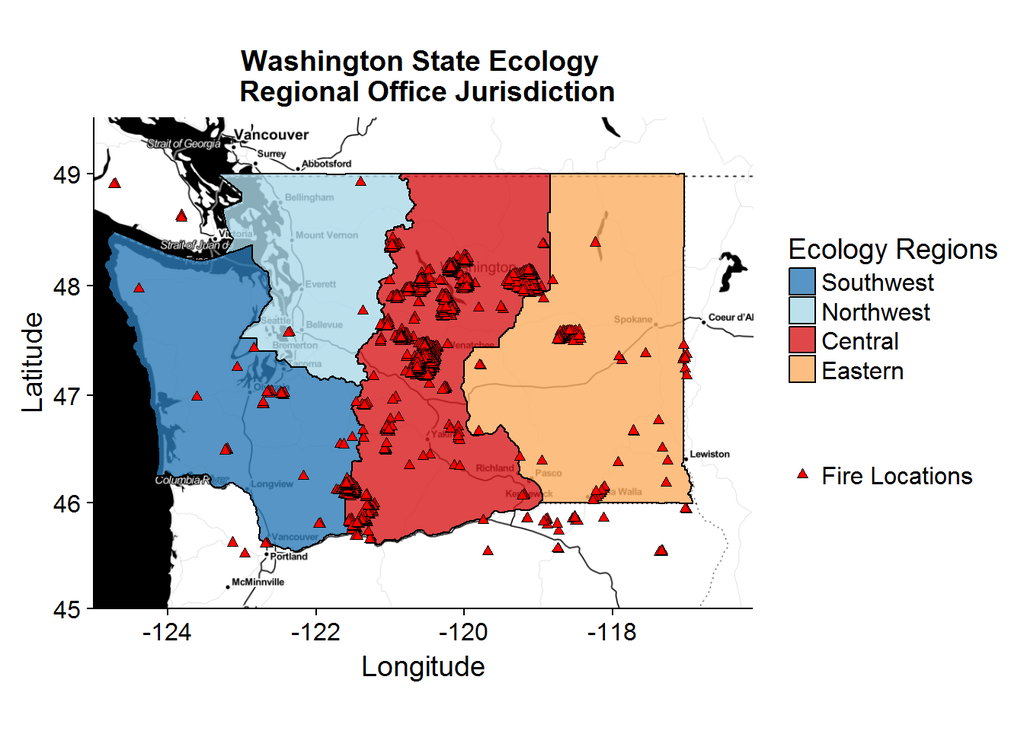

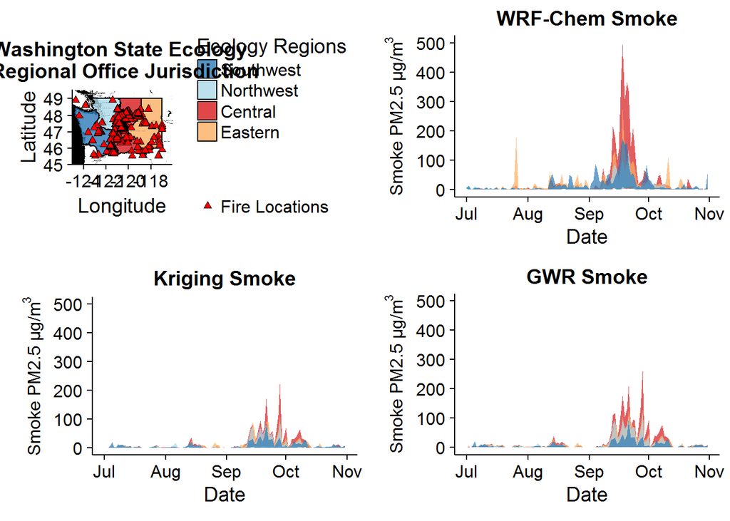

## Days of Smoke In Washington

Here is a figure of the days from July 1st to October 31st 2012 where PM<sub>2.5</sub> exceeded >10.

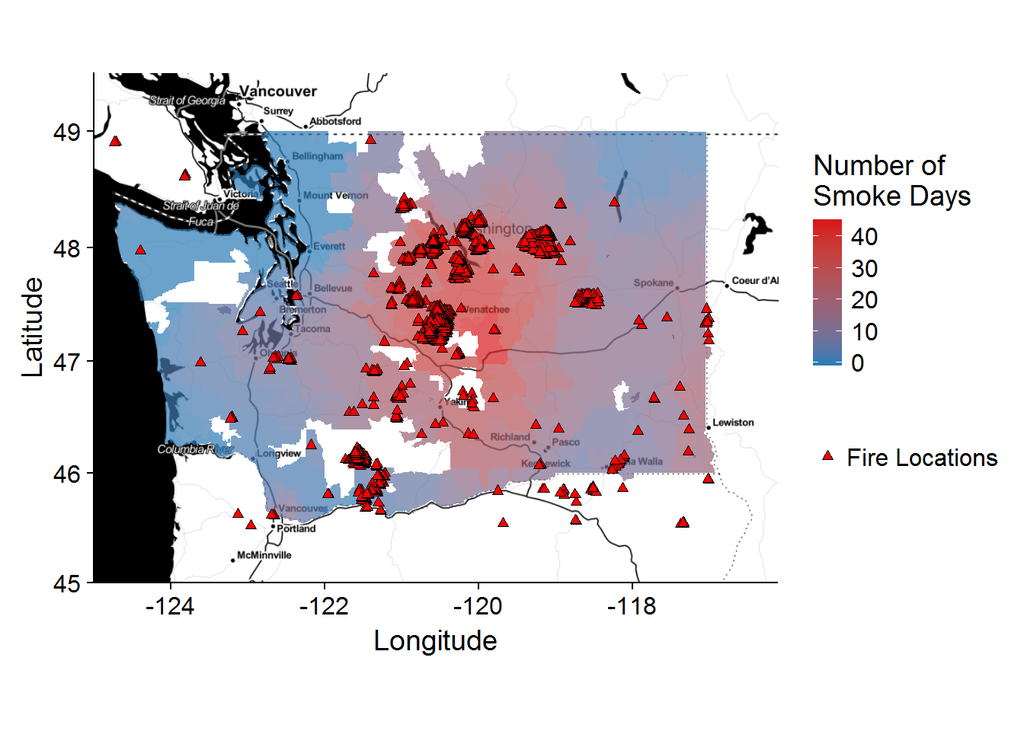

## Population-Weighted PM<sub>2.5</sub> Assigned by Zip Code

### Descriptives

Note for following tables: I wrote out ‘Greater than rather’ than using ‘>’ as it was increasing the following font and looked weird.

| Number of cases for each outcome observed from July 1st to October 31st, 2012 | Number of cases for each outcome observed from July 1st to October 31st, 2012 Outcome | Number of cases for each outcome observed from July 1st to October 31st, 2012 Cases n | Number of cases for each outcome observed from July 1st to October 31st, 2012 | Number of cases for each outcome observed from July 1st to October 31st, 2012 Age Category Less than 15 | Number of cases for each outcome observed from July 1st to October 31st, 2012 Age Category (%) | Number of cases for each outcome observed from July 1st to October 31st, 2012 Age Category 15 to 65 | Number of cases for each outcome observed from July 1st to October 31st, 2012 Age Category (%) | Number of cases for each outcome observed from July 1st to October 31st, 2012 Age Category Greater than 65 | Number of cases for each outcome observed from July 1st to October 31st, 2012 Age Category (%) | Number of cases for each outcome observed from July 1st to October 31st, 2012 | Number of cases for each outcome observed from July 1st to October 31st, 2012 Sex Female | Number of cases for each outcome observed from July 1st to October 31st, 2012 Sex (%) | Number of cases for each outcome observed from July 1st to October 31st, 2012 Sex Male | Number of cases for each outcome observed from July 1st to October 31st, 2012 Sex (%) |
| --- | --- | --- | --- | --- | --- | --- | --- | --- | --- | --- | --- | --- | --- | --- |
| 1 | All Respiratory | 9813.0 |  | 1313.0 | 13.4 | 3595.0 | 36.6 | 4905.0 | 50.0 |  | 5088.0 | 51.8 | 4725.0 | 48.2 |
| 2 | Asthma | 1467.0 |  | 655.0 | 44.6 | 611.0 | 41.6 | 201.0 | 13.7 |  | 813.0 | 55.4 | 654.0 | 44.6 |
| 3 | COPD | 1714.0 |  | 6.0 | 0.4 | 669.0 | 39.0 | 1039.0 | 60.6 |  | 982.0 | 57.3 | 732.0 | 42.7 |
| 4 | Pneumonia | 3189.0 |  | 239.0 | 7.5 | 1061.0 | 33.3 | 1889.0 | 59.2 |  | 1648.0 | 51.7 | 1541.0 | 48.3 |
| 5 | Acute Bronchitis | 289.0 |  | 140.0 | 48.4 | 74.0 | 25.6 | 75.0 | 26.0 |  | 145.0 | 50.2 | 144.0 | 49.8 |
| 6 | Cardiovascular Disease | 17831.0 |  | 68.0 | 0.4 | 6482.0 | 36.4 | 11281.0 | 63.3 |  | 8473.0 | 47.5 | 9358.0 | 52.5 |
| 7 | Arrhythmia | 3302.0 |  | 12.0 | 0.4 | 1018.0 | 30.8 | 2272.0 | 68.8 |  | 1657.0 | 50.2 | 1645.0 | 49.8 |
| 8 | Cerebrovascular Disease | 4305.0 |  | 10.0 | 0.2 | 1296.0 | 30.1 | 2999.0 | 69.7 |  | 2258.0 | 52.5 | 2047.0 | 47.5 |
| 9 | Heart Failure | 3021.0 |  | 6.0 | 0.2 | 781.0 | 25.9 | 2234.0 | 73.9 |  | 1475.0 | 48.8 | 1546.0 | 51.2 |
| 10 | Ischemic Heart Disease | 2972.0 |  | 0.0 | 0.0 | 1230.0 | 41.4 | 1742.0 | 58.6 |  | 1149.0 | 38.7 | 1823.0 | 61.3 |
| 11 | Myocardial Infarction | 2736.0 |  | 0.0 | 0.0 | 1131.0 | 41.3 | 1605.0 | 58.7 |  | 1019.0 | 37.2 | 1717.0 | 62.8 |
| 12 | Broken Arm | 325.0 |  | 50.0 | 15.4 | 172.0 | 52.9 | 103.0 | 31.7 |  | 149.0 | 45.8 | 176.0 | 54.2 |

### Background on Time-Stratified Case-Crossover Design

The original time-stratified case-crossover design suggested picking referent periods based on any potential time-varying confounding, *a priori*. For example, if day of the week and the month of the exposure sequence is of concern, one might pick referents in the same day of the week and the same day of the month. The papers that discuss and support the use of a time-stratified design are the Janes et al. 2005 **Epidemiology paper**, *Case-Crossover Analyses of Air Pollution Exposure Data; Referent Selection Strategies and Their Implication for Bias*.

The authors state that with the time-stratified design, the *a priori* selection of the referent period on the same day of the week within the same month has the following benefits:

More referent periods is better for statistical efficiency, but there is a tradeoff, where additional referent periods may introduce what they call ‘overlap bias’, which they mathmatically define in Janes 2005 **Statistics in Medicine** paper, *Overlap Bias in the Case-Crossover Design, with Applications to Air Pollution Exposures*. Basically this bias occurs when the exposure assigned in the referent period is conditional on the strategy used to define the referent period.

As Janes et al. state in their 2005 **Statistics in Medicine** paper:

> *Two of the main strengths of the case-crossover design in the air pollution context are that it controls fixed confounders and allows for control over time-dependent confounders by design. Choosing referents that are restricted to the same day of the week and season as the index time will control for these effects. Though we have not examined the degree to which various referent selection strategies control bias due to confounding, several points are clear. Referents that are closer to the index time will achieve greater control of seasonal confounding. However, sampling referents closer to the index time will also result in a loss of power due to less heterogeneity in the exposure series, and a smaller number of referents will also result in lower power.*

I will use both Janes 2005 papers in **Epidemiology** and **Statistics in Medicine** to justify the use of the time-stratified design.

This design has an advantage over other case-crossover designs I’ve explored in that you can use more referent times, and as the exposure at these times are averaged for each subject over a set time period, this balances out some of the more extreme values of PM<sub>2.5</sub> that may persist over a couple weeks due to wildfire smoke.

### Time-Stratified Case-Crossover (referents same day of week within fire season July - October)

For these analyses and for the final results in the paper, I used referents within the entire wildfire season (July to October). This time-stratified referent strategy allows even more referent observations to average to ‘smooth’ out some of those extreme PM<sub>2.5</sub> concentrations in some referent periods. For my sensitivity analysis of varying referent periods, please see other scripts.

Adjusting for CDC Met Variables: Rish has provided zip-level meteorologic data on wind speed, precipitation, relative humidity, and temperature. Note a slight difference that will likely need to be addressed in discussion is that these measures are weighted based on census tract, not on the WRF grid like our measures of smoke.

| Association between a 10 ug/m^3 in PM2.5 and Health Outcomes | Association between a 10 ug/m^3 in PM2.5 and Health Outcomes Method | Association between a 10 ug/m^3 in PM2.5 and Health Outcomes Obs. | Association between a 10 ug/m^3 in PM2.5 and Health Outcomes Events | Association between a 10 ug/m^3 in PM2.5 and Health Outcomes OR† | Association between a 10 ug/m^3 in PM2.5 and Health Outcomes | Association between a 10 ug/m^3 in PM2.5 and Health Outcomes 95% CI Lower | Association between a 10 ug/m^3 in PM2.5 and Health Outcomes 95% CI Upper |
| --- | --- | --- | --- | --- | --- | --- | --- |
| All Respiratory |  |  |  |  |  |  |  |
| 1 | WRF-Chem Smoke | 171849 | 9764 | 1.023 |  | 1.002 | 1.045 |
| 2 | Kriging Smoke | 171849 | 9764 | 1.063 |  | 1.031 | 1.097 |
| 3 | GWR Smoke | 171849 | 9764 | 1.050 |  | 1.023 | 1.078 |
| Asthma |  |  |  |  |  |  |  |
| 4 | WRF-Chem Smoke | 25690 | 1459 | 1.099 |  | 1.059 | 1.141 |
| 5 | Kriging Smoke | 25690 | 1459 | 1.084 |  | 1.014 | 1.158 |
| 6 | GWR Smoke | 25690 | 1459 | 1.074 |  | 1.017 | 1.134 |
| COPD |  |  |  |  |  |  |  |
| 7 | WRF-Chem Smoke | 30046 | 1706 | 0.984 |  | 0.929 | 1.042 |
| 8 | Kriging Smoke | 30046 | 1706 | 1.103 |  | 1.034 | 1.177 |
| 9 | GWR Smoke | 30046 | 1706 | 1.082 |  | 1.024 | 1.143 |
| Pneumonia |  |  |  |  |  |  |  |
| 10 | WRF-Chem Smoke | 55766 | 3169 | 1.019 |  | 0.980 | 1.059 |
| 11 | Kriging Smoke | 55766 | 3169 | 1.071 |  | 1.011 | 1.135 |
| 12 | GWR Smoke | 55766 | 3169 | 1.053 |  | 1.002 | 1.107 |
| Acute Bronchitis |  |  |  |  |  |  |  |
| 13 | WRF-Chem Smoke | 5069 | 288 | 1.042 |  | 0.904 | 1.202 |
| 14 | Kriging Smoke | 5069 | 288 | 1.088 |  | 0.871 | 1.360 |
| 15 | GWR Smoke | 5069 | 288 | 1.076 |  | 0.881 | 1.316 |
| Cardiovascular Disease |  |  |  |  |  |  |  |
| 16 | WRF-Chem Smoke | 311860 | 17734 | 1.006 |  | 0.989 | 1.023 |
| 17 | Kriging Smoke | 311860 | 17734 | 1.005 |  | 0.979 | 1.031 |
| 18 | GWR Smoke | 311860 | 17734 | 1.004 |  | 0.982 | 1.026 |
| Arrhythmia |  |  |  |  |  |  |  |
| 19 | WRF-Chem Smoke | 57710 | 3279 | 0.998 |  | 0.959 | 1.038 |
| 20 | Kriging Smoke | 57710 | 3279 | 1.011 |  | 0.953 | 1.073 |
| 21 | GWR Smoke | 57710 | 3279 | 1.010 |  | 0.961 | 1.062 |
| Cerebrovascular Disease |  |  |  |  |  |  |  |
| 22 | WRF-Chem Smoke | 75211 | 4279 | 1.034 |  | 1.003 | 1.066 |
| 23 | Kriging Smoke | 75211 | 4279 | 1.004 |  | 0.955 | 1.056 |
| 24 | GWR Smoke | 75211 | 4279 | 1.008 |  | 0.966 | 1.051 |
| Heart Failure |  |  |  |  |  |  |  |
| 25 | WRF-Chem Smoke | 53001 | 3011 | 0.997 |  | 0.954 | 1.041 |
| 26 | Kriging Smoke | 53001 | 3011 | 1.015 |  | 0.951 | 1.083 |
| 27 | GWR Smoke | 53001 | 3011 | 1.016 |  | 0.961 | 1.073 |
| Ischemic Heart Disease |  |  |  |  |  |  |  |
| 28 | WRF-Chem Smoke | 51845 | 2949 | 0.971 |  | 0.926 | 1.018 |
| 29 | Kriging Smoke | 51845 | 2949 | 1.002 |  | 0.939 | 1.069 |
| 30 | GWR Smoke | 51845 | 2949 | 0.998 |  | 0.944 | 1.056 |
| Myocardial Infarction |  |  |  |  |  |  |  |
| 31 | WRF-Chem Smoke | 47806 | 2719 | 0.981 |  | 0.935 | 1.029 |
| 32 | Kriging Smoke | 47806 | 2719 | 1.008 |  | 0.942 | 1.079 |
| 33 | GWR Smoke | 47806 | 2719 | 1.005 |  | 0.948 | 1.065 |
| Broken Arm |  |  |  |  |  |  |  |
| 34 | WRF-Chem Smoke | 5633 | 321 | 1.045 |  | 0.940 | 1.162 |
| 35 | Kriging Smoke | 5633 | 321 | 1.033 |  | 0.833 | 1.281 |
| 36 | GWR Smoke | 5633 | 321 | 1.035 |  | 0.867 | 1.236 |

† Adjusted for CDC temperature, relatively humidity, wind speed, and precipitation; accounting for subject. Time-stratified: referent periods matched to events on same day of week within July to October fire season.

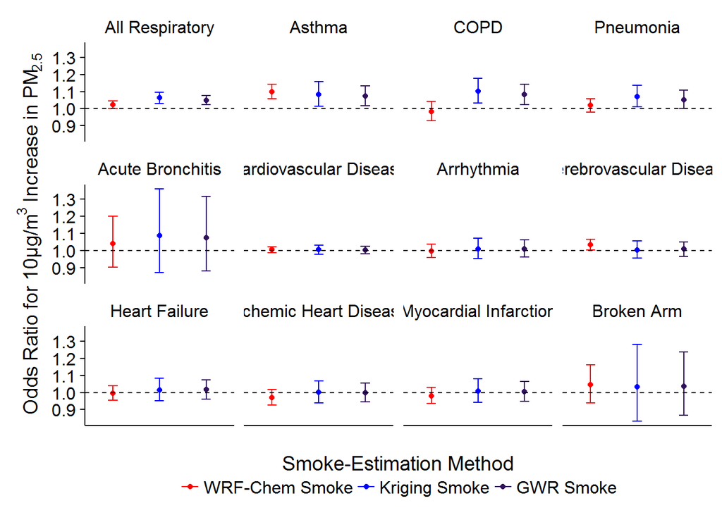

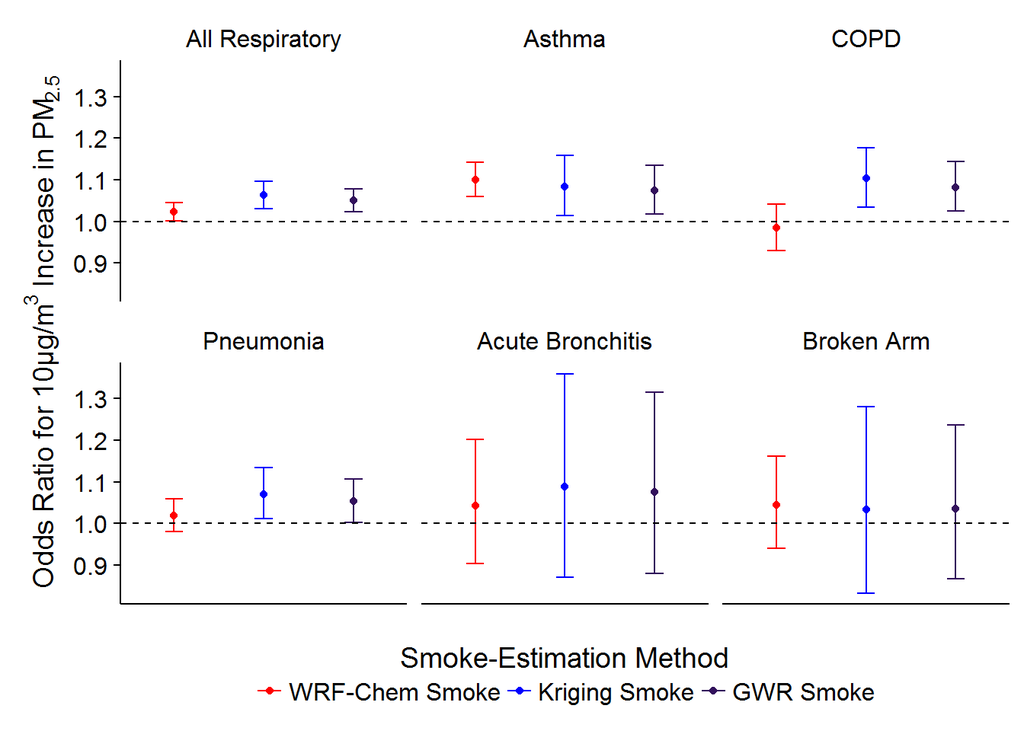

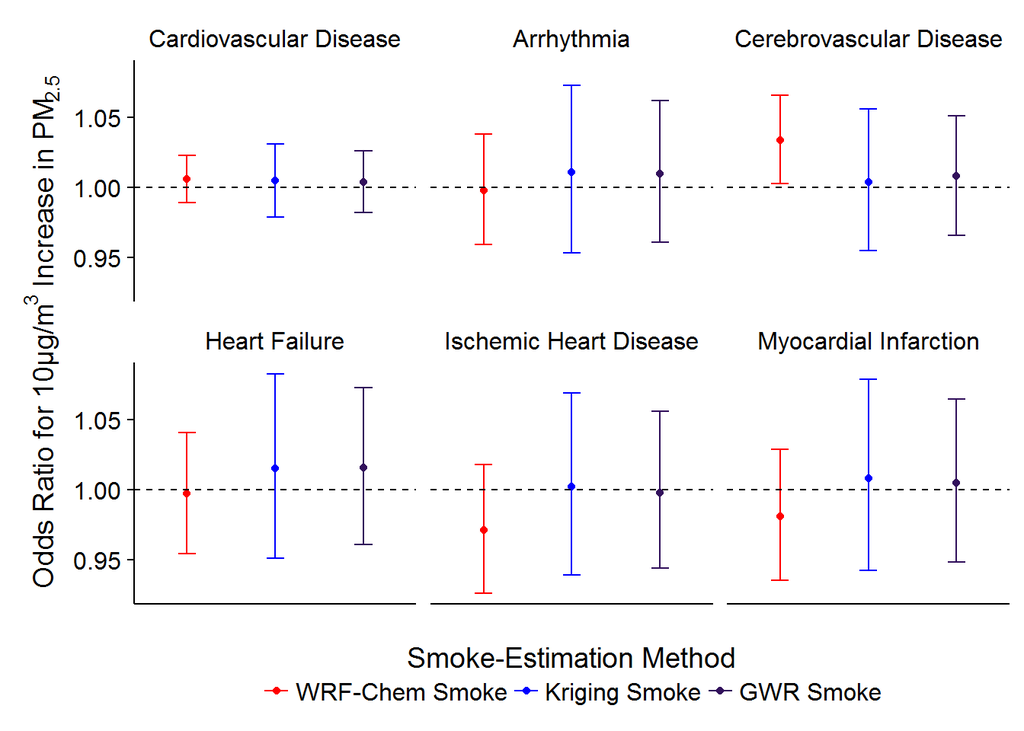

#### Result Summary: Time-Stratified Case-Crossover Design (same day of week within the season)

A general interpretation is as follows: A 10 $\mu$g/m<sup>3</sup> increase in PM<sub>2.5</sub> attributed to wildfire smoke was associated with a X% increase in the risk for a health event. Where X% is the odds ratio - 1 (e.g. OR of 1.20 - 1 = 20% increase). Note that the odds ratio approximates the relative risk in this case due to the rare outcome assumption in that the calcuation for an odds ratio is similar to risk ratio calcuation.

When adjusting for the CDC met variables, the results are slightly attenuated when compared to my adjustments with just WRF-Temp, but my overall conclusions do not change much.

### Time-Stratified by Age Categories

For some outcomes, there may be some evidence of effect modificaiton, like COPD, where >65 age group is at significant risk. However, the point estimates are relatively similar for the 15 to 65 strata, just not significant. Some error bars are not shown as they are too wide; usually <15 age category where there are only a handful of outcomes.

| Association between a 10 ug/m^3 in PM2.5 geo smoke and health outcomes stratified by age | Association between a 10 ug/m^3 in PM2.5 geo smoke and health outcomes stratified by age Est Method | Association between a 10 ug/m^3 in PM2.5 geo smoke and health outcomes stratified by age Age Group | Association between a 10 ug/m^3 in PM2.5 geo smoke and health outcomes stratified by age Events | Association between a 10 ug/m^3 in PM2.5 geo smoke and health outcomes stratified by age OR† | Association between a 10 ug/m^3 in PM2.5 geo smoke and health outcomes stratified by age | Association between a 10 ug/m^3 in PM2.5 geo smoke and health outcomes stratified by age 95% CI Lower | Association between a 10 ug/m^3 in PM2.5 geo smoke and health outcomes stratified by age 95% CI Upper |
| --- | --- | --- | --- | --- | --- | --- | --- |
| All Respiratory |  |  |  |  |  |  |  |
| 1 | WRF-Chem Smoke | Less than 15 | 1308 | 1.058 |  | 1.010 | 1.109 |
| 2 | GWR Smoke | Less than 15 | 1308 | 1.070 |  | 1.002 | 1.143 |
| 3 | WRF-Chem Smoke | 15-65 | 3574 | 1.023 |  | 0.986 | 1.061 |
| 4 | GWR Smoke | 15-65 | 3574 | 1.034 |  | 0.988 | 1.082 |
| 5 | WRF-Chem Smoke | Greater than 65 | 4882 | 1.011 |  | 0.980 | 1.043 |
| 6 | GWR Smoke | Greater than 65 | 4882 | 1.054 |  | 1.016 | 1.094 |
| Asthma |  |  |  |  |  |  |  |
| 7 | WRF-Chem Smoke | Less than 15 | 654 | 1.116 |  | 1.050 | 1.185 |
| 8 | GWR Smoke | Less than 15 | 654 | 1.076 |  | 0.987 | 1.173 |
| 9 | WRF-Chem Smoke | 15-65 | 605 | 1.091 |  | 1.029 | 1.158 |
| 10 | GWR Smoke | 15-65 | 605 | 1.055 |  | 0.974 | 1.143 |
| 11 | WRF-Chem Smoke | Greater than 65 | 200 | 1.094 |  | 1.007 | 1.188 |
| 12 | GWR Smoke | Greater than 65 | 200 | 1.173 |  | 1.003 | 1.370 |
| COPD |  |  |  |  |  |  |  |
| 13 | WRF-Chem Smoke | Less than 15 | 6 | 1.870 |  | 0.945 | 3.700 |
| 14 | GWR Smoke | Less than 15 | 6 | 0.477 |  | 0.044 | 5.115 |
| 15 | WRF-Chem Smoke | 15-65 | 667 | 0.997 |  | 0.901 | 1.104 |
| 16 | GWR Smoke | 15-65 | 667 | 1.046 |  | 0.917 | 1.194 |
| 17 | WRF-Chem Smoke | Greater than 65 | 1033 | 0.972 |  | 0.905 | 1.045 |
| 18 | GWR Smoke | Greater than 65 | 1033 | 1.091 |  | 1.027 | 1.158 |
| Pneumonia |  |  |  |  |  |  |  |
| 19 | WRF-Chem Smoke | Less than 15 | 236 | 1.015 |  | 0.887 | 1.161 |
| 20 | GWR Smoke | Less than 15 | 236 | 1.081 |  | 0.921 | 1.268 |
| 21 | WRF-Chem Smoke | 15-65 | 1052 | 1.031 |  | 0.961 | 1.105 |
| 22 | GWR Smoke | 15-65 | 1052 | 1.018 |  | 0.922 | 1.123 |
| 23 | WRF-Chem Smoke | Greater than 65 | 1881 | 1.014 |  | 0.964 | 1.065 |
| 24 | GWR Smoke | Greater than 65 | 1881 | 1.065 |  | 1.001 | 1.133 |
| Acute Bronchitis |  |  |  |  |  |  |  |
| 25 | WRF-Chem Smoke | Less than 15 | 140 | 1.059 |  | 0.878 | 1.276 |

[output cut: 54 more lines]

† Adjusted for CDC temperature, wind speed, relative humidity, precipitation, and accounting for subject. Time-stratified: referent periods matched to events on same day of week within July to October fire season.

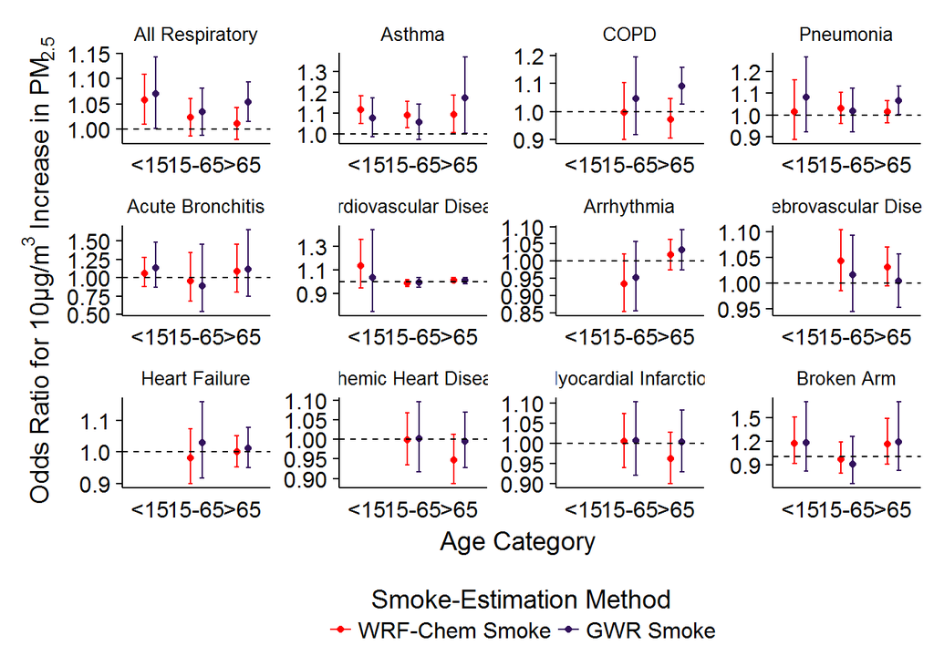

### Seasonal Time-Stratified by Sex

Association with smoke PM<sub>2.5</sub> and health outcomes stratified by sex. May be some evidence of effect modification by sex, particularly where males appear to be at greater risk for certain CVD outcomes with increasing smoke. However, only marginally significant. Also, broken arm estimate seems a little strange, suggesting females at greater risk too. Larger sample size may help to answer this.

| Association between a 10 ug/m^3 in PM2.5 geo smoke and health outcomes stratified by sex | Association between a 10 ug/m^3 in PM2.5 geo smoke and health outcomes stratified by sex Est Method | Association between a 10 ug/m^3 in PM2.5 geo smoke and health outcomes stratified by sex Sex Strata | Association between a 10 ug/m^3 in PM2.5 geo smoke and health outcomes stratified by sex Events | Association between a 10 ug/m^3 in PM2.5 geo smoke and health outcomes stratified by sex OR† | Association between a 10 ug/m^3 in PM2.5 geo smoke and health outcomes stratified by sex | Association between a 10 ug/m^3 in PM2.5 geo smoke and health outcomes stratified by sex 95% CI Lower | Association between a 10 ug/m^3 in PM2.5 geo smoke and health outcomes stratified by sex 95% CI Upper |
| --- | --- | --- | --- | --- | --- | --- | --- |
| All Respiratory |  |  |  |  |  |  |  |
| 1 | WRF-Chem Smoke | Male | 4701 | 1.019 |  | 0.988 | 1.050 |
| 2 | GWR Smoke | Male | 4701 | 1.051 |  | 1.014 | 1.089 |
| 3 | WRF-Chem Smoke | Female | 5063 | 1.027 |  | 0.998 | 1.058 |
| 4 | GWR Smoke | Female | 5063 | 1.049 |  | 1.008 | 1.090 |
| Asthma |  |  |  |  |  |  |  |
| 5 | WRF-Chem Smoke | Male | 652 | 1.111 |  | 1.051 | 1.175 |
| 6 | GWR Smoke | Male | 652 | 1.075 |  | 0.994 | 1.163 |
| 7 | WRF-Chem Smoke | Female | 807 | 1.090 |  | 1.036 | 1.146 |
| 8 | GWR Smoke | Female | 807 | 1.073 |  | 0.995 | 1.156 |
| COPD |  |  |  |  |  |  |  |
| 9 | WRF-Chem Smoke | Male | 730 | 0.945 |  | 0.860 | 1.038 |
| 10 | GWR Smoke | Male | 730 | 1.101 |  | 1.025 | 1.181 |
| 11 | WRF-Chem Smoke | Female | 976 | 1.016 |  | 0.943 | 1.094 |
| 12 | GWR Smoke | Female | 976 | 1.054 |  | 0.964 | 1.153 |
| Pneumonia |  |  |  |  |  |  |  |
| 13 | WRF-Chem Smoke | Male | 1529 | 1.027 |  | 0.973 | 1.083 |
| 14 | GWR Smoke | Male | 1529 | 1.059 |  | 0.993 | 1.130 |
| 15 | WRF-Chem Smoke | Female | 1640 | 1.011 |  | 0.956 | 1.069 |
| 16 | GWR Smoke | Female | 1640 | 1.045 |  | 0.967 | 1.128 |
| Acute Bronchitis |  |  |  |  |  |  |  |
| 17 | WRF-Chem Smoke | Male | 144 | 1.136 |  | 0.953 | 1.354 |
| 18 | GWR Smoke | Male | 144 | 1.340 |  | 1.061 | 1.692 |
| 19 | WRF-Chem Smoke | Female | 144 | 0.925 |  | 0.725 | 1.178 |
| 20 | GWR Smoke | Female | 144 | 0.714 |  | 0.475 | 1.073 |
| Cardiovascular Disease |  |  |  |  |  |  |  |
| 21 | WRF-Chem Smoke | Male | 9304 | 1.018 |  | 0.996 | 1.041 |
| 22 | GWR Smoke | Male | 9304 | 1.024 |  | 0.995 | 1.054 |
| 23 | WRF-Chem Smoke | Female | 8430 | 0.989 |  | 0.963 | 1.016 |
| 24 | GWR Smoke | Female | 8430 | 0.981 |  | 0.949 | 1.014 |
| Arrhythmia |  |  |  |  |  |  |  |
| 25 | WRF-Chem Smoke | Male | 1633 | 1.006 |  | 0.951 | 1.064 |
| 26 | GWR Smoke | Male | 1633 | 1.004 |  | 0.926 | 1.088 |
| 27 | WRF-Chem Smoke | Female | 1646 | 0.991 |  | 0.936 | 1.048 |
| 28 | GWR Smoke | Female | 1646 | 1.016 |  | 0.953 | 1.082 |
| Cerebrovascular Disease |  |  |  |  |  |  |  |
| 29 | WRF-Chem Smoke | Male | 2031 | 1.044 |  | 1.001 | 1.088 |
| 30 | GWR Smoke | Male | 2031 | 1.021 |  | 0.964 | 1.081 |
| 31 | WRF-Chem Smoke | Female | 2248 | 1.024 |  | 0.978 | 1.072 |
| 32 | GWR Smoke | Female | 2248 | 0.994 |  | 0.933 | 1.058 |
| Heart Failure |  |  |  |  |  |  |  |
| 33 | WRF-Chem Smoke | Male | 1540 | 1.015 |  | 0.961 | 1.072 |
| 34 | GWR Smoke | Male | 1540 | 1.042 |  | 0.968 | 1.122 |
| 35 | WRF-Chem Smoke | Female | 1471 | 0.971 |  | 0.905 | 1.042 |
| 36 | GWR Smoke | Female | 1471 | 0.988 |  | 0.908 | 1.074 |
| Ischemic Heart Disease |  |  |  |  |  |  |  |
| 37 | WRF-Chem Smoke | Male | 1810 | 1.006 |  | 0.954 | 1.062 |
| 38 | GWR Smoke | Male | 1810 | 1.053 |  | 0.989 | 1.121 |
| 39 | WRF-Chem Smoke | Female | 1139 | 0.902 |  | 0.825 | 0.987 |
| 40 | GWR Smoke | Female | 1139 | 0.883 |  | 0.785 | 0.994 |
| Myocardial Infarction |  |  |  |  |  |  |  |
| 41 | WRF-Chem Smoke | Male | 1707 | 1.018 |  | 0.965 | 1.072 |
| 42 | GWR Smoke | Male | 1707 | 1.059 |  | 0.993 | 1.130 |
| 43 | WRF-Chem Smoke | Female | 1012 | 0.902 |  | 0.820 | 0.992 |
| 44 | GWR Smoke | Female | 1012 | 0.882 |  | 0.777 | 1.000 |
| Broken Arm |  |  |  |  |  |  |  |
| 45 | WRF-Chem Smoke | Male | 172 | 0.973 |  | 0.798 | 1.187 |
| 46 | GWR Smoke | Male | 172 | 0.883 |  | 0.629 | 1.241 |
| 47 | WRF-Chem Smoke | Female | 149 | 1.176 |  | 0.987 | 1.400 |
| 48 | GWR Smoke | Female | 149 | 1.234 |  | 0.955 | 1.595 |

† Adjusted for temperature, accounting for subject. Time-stratified: referent periods matched to events on same day of week within July to October fire season.

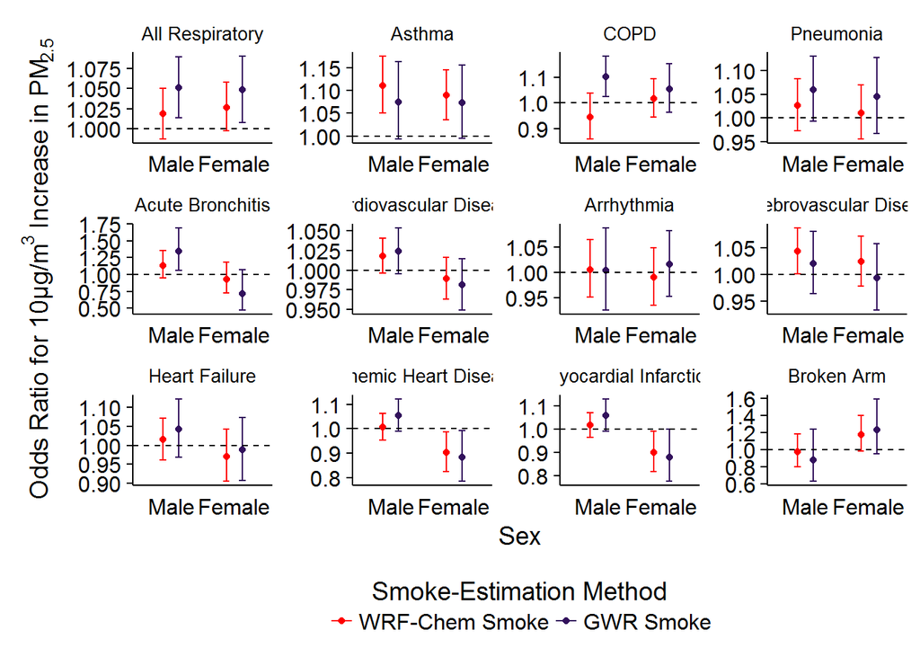

### Lag Periods

Lag period adjusted for CDC met variables.

| Association between a 10 ug/m^3 in PM2.5 geo smoke and health outcomes by lagged days | Association between a 10 ug/m^3 in PM2.5 geo smoke and health outcomes by lagged days Est Method | Association between a 10 ug/m^3 in PM2.5 geo smoke and health outcomes by lagged days Lagged Days | Association between a 10 ug/m^3 in PM2.5 geo smoke and health outcomes by lagged days Events | Association between a 10 ug/m^3 in PM2.5 geo smoke and health outcomes by lagged days OR† | Association between a 10 ug/m^3 in PM2.5 geo smoke and health outcomes by lagged days | Association between a 10 ug/m^3 in PM2.5 geo smoke and health outcomes by lagged days 95% CI Lower | Association between a 10 ug/m^3 in PM2.5 geo smoke and health outcomes by lagged days 95% CI Upper |
| --- | --- | --- | --- | --- | --- | --- | --- |
| All Respiratory |  |  |  |  |  |  |  |
| 1 | WRF-Chem Smoke | 0 | 9764 | 1.023 |  | 1.002 | 1.045 |
| 2 | WRF-Chem Smoke | 1 | 9695 | 1.022 |  | 1.001 | 1.044 |
| 3 | WRF-Chem Smoke | 2 | 9610 | 1.020 |  | 0.999 | 1.042 |
| 4 | WRF-Chem Smoke | 3 | 9516 | 1.016 |  | 0.994 | 1.038 |
| 5 | WRF-Chem Smoke | 4 | 9454 | 1.026 |  | 1.004 | 1.047 |
| 6 | WRF-Chem Smoke | 5 | 9376 | 1.023 |  | 1.002 | 1.046 |
| 7 | GWR Smoke | 0 | 9764 | 1.050 |  | 1.023 | 1.078 |
| 8 | GWR Smoke | 1 | 9695 | 1.042 |  | 1.014 | 1.071 |
| 9 | GWR Smoke | 2 | 9610 | 1.043 |  | 1.014 | 1.072 |
| 10 | GWR Smoke | 3 | 9516 | 1.052 |  | 1.027 | 1.079 |
| 11 | GWR Smoke | 4 | 9454 | 1.040 |  | 1.014 | 1.068 |
| 12 | GWR Smoke | 5 | 9376 | 1.033 |  | 1.006 | 1.061 |
| Asthma |  |  |  |  |  |  |  |
| 13 | WRF-Chem Smoke | 0 | 1459 | 1.099 |  | 1.059 | 1.141 |
| 14 | WRF-Chem Smoke | 1 | 1449 | 1.073 |  | 1.035 | 1.112 |
| 15 | WRF-Chem Smoke | 2 | 1444 | 1.062 |  | 1.022 | 1.104 |
| 16 | WRF-Chem Smoke | 3 | 1434 | 1.061 |  | 1.021 | 1.102 |
| 17 | WRF-Chem Smoke | 4 | 1431 | 1.070 |  | 1.029 | 1.112 |
| 18 | WRF-Chem Smoke | 5 | 1427 | 1.070 |  | 1.028 | 1.114 |
| 19 | GWR Smoke | 0 | 1459 | 1.074 |  | 1.017 | 1.134 |
| 20 | GWR Smoke | 1 | 1449 | 1.048 |  | 0.990 | 1.110 |
| 21 | GWR Smoke | 2 | 1444 | 1.074 |  | 1.010 | 1.142 |
| 22 | GWR Smoke | 3 | 1434 | 1.082 |  | 1.023 | 1.144 |
| 23 | GWR Smoke | 4 | 1431 | 1.059 |  | 1.004 | 1.117 |
| 24 | GWR Smoke | 5 | 1427 | 1.080 |  | 1.020 | 1.144 |
| COPD |  |  |  |  |  |  |  |
| 25 | WRF-Chem Smoke | 0 | 1706 | 0.984 |  | 0.929 | 1.042 |
| 26 | WRF-Chem Smoke | 1 | 1690 | 1.006 |  | 0.955 | 1.060 |
| 27 | WRF-Chem Smoke | 2 | 1673 | 1.027 |  | 0.981 | 1.075 |

[output cut: 126 more lines]

† Adjusted for lagged CDC temperature, windspeed, relative humidity, and precipitation, accounting for subject.

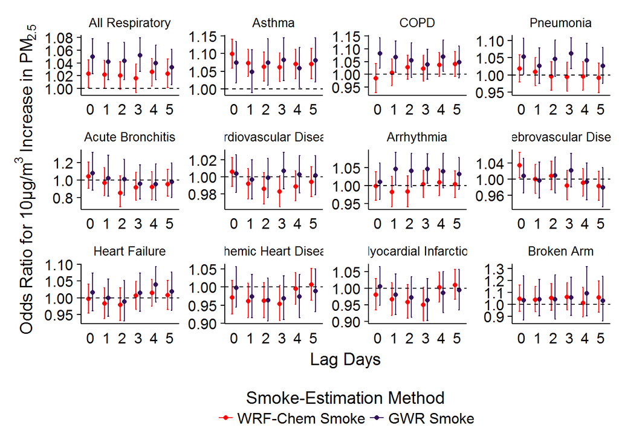